# 1_Cohort_Study_Risk_Measures_Confounding_and_Interaction

```
    No  Yes
```

No 1834 311 Yes 1762 333

Table 1. Overall 2×2 contingency table: Smoking vs. 10-year CHD

|  | No | Yes |
| --- | --- | --- |
| No | 1834 | 311 |
| Yes | 1762 | 333 |

```
         Outcome+    Outcome-      Total                 Inc risk *
```

Exposure+ 1834 311 2145 85.50 (83.94 to 86.97) Exposure- 1762 333 2095 84.11 (82.47 to 85.65) Total 3596 644 4240 84.81 (83.70 to 85.88)

## Point estimates and 95% CIs:

Inc risk ratio 1.02 (0.99, 1.04) Inc odds ratio 1.11 (0.94, 1.32) Attrib risk in the exposed * 1.40 (-0.77, 3.56) Attrib fraction in the exposed (%) 1.63 (-0.91, 4.12) Attrib risk in the population * 0.71 (-1.20, 2.61) Attrib fraction in the population (%) 0.83 (0.27, 1.47) ——————————————————————- Uncorrected chi2 test that OR = 1: chi2(1) = 1.604 Pr>chi2 = 0.205 Fisher exact test that OR = 1: Pr>chi2 = 0.215 Wald confidence limits CI: confidence interval * Outcomes per 100 population units

| est | lower | upper |
| --- | --- | --- |
| 1.017 | 0.991 | 1.043 |

Table 2b. Risk Difference (RD)

|  | est | lower | upper |
| --- | --- | --- | --- |
| 3 | 1.396 | -0.765 | 3.557 |

Table 2c. Odds Ratio (OR)

|  | est | lower | upper |
| --- | --- | --- | --- |
| 2 | 1.114 | 0.942 | 1.318 |

| Stratum | RR | 95% LCL | 95% UCL | N_stratum |
| --- | --- | --- | --- | --- |
| Female | 0.973 | 0.944 | 1.003 | 2420 |
| Male | 1.045 | 1.000 | 1.092 | 1820 |

| Stratum | RR | 95% LCL | 95% UCL | N_stratum |
| --- | --- | --- | --- | --- |
| [0,45) | 1.046 | 1.019 | 1.073 | 1427 |
| [45,60) | 1.060 | 1.020 | 1.102 | 2123 |
| [60,+) | 1.046 | 0.944 | 1.159 | 690 |

Table 5. Mantel–Haenszel common ORs (controlling for sex or age group)

| Strata | MH_common_OR | p_value |
| --- | --- | --- |
| Sex | 1.012 | 0.927 |
| Age group | 1.439 | 0.000 |

Table 6. Comparison of crude and adjusted risk ratios (RR) for smoking and 10-year CHD

| Model | RR | LCL | UCL |
| --- | --- | --- | --- |
| Crude (unadjusted) | 1.096 | 0.951 | 1.264 |
| Adjusted (age + diab + hyp) | 1.402 | 1.220 | 1.610 |

**Confounding assessment:** Adjusting for age, diabetes, and hypertension changed the RR by 27.8%. This exceeds the 10% threshold, indicating *substantial confounding* by these covariates.

Table 7. Multiplicative interaction between smoking and sex (from Poisson regression)

| term | RR | LCL | UCL | p.value |
| --- | --- | --- | --- | --- |
| smokeYes:sexMale | 1.292 | 0.967 | 1.727 | 0.083 |

Table 8. Additive interaction between smoking and sex (RERI, AP, S)

| Metric | Value |
| --- | --- |
| RERI (Relative Excess Risk due to Interaction) | 0.060 |
| AP (Attributable Proportion due to Interaction) | 0.295 |
| S (Synergy Index) | 8.009 |

**Interpretation:** • The multiplicative interaction term (smoking × sex) had RR = 1.29 (95% CI 0.97–1.73). This indicates no statistically significant interaction on the multiplicative scale. • On the additive scale, RERI = 0.060, AP = 0.295, S = 8.009. These positive values indicate that the joint effect of smoking and male sex on CHD exceeds the sum of their individual effects, consistent with a *positive additive interaction*.

**Table 9. Baseline characteristics by smoking status**

| **Variable** | **No** N = 2,145<sup>1</sup> | **Yes** N = 2,095<sup>1</sup> | **p-value**<sup>2</sup> |
| --- | --- | --- | --- |
| sex |  |  | <0.001 |
| Female | 1,431 (67%) | 989 (47%) |  |
| Male | 714 (33%) | 1,106 (53%) |  |
| age | 51 (9) | 48 (8) | <0.001 |
| age_grp |  |  | <0.001 |
| [0,45) | 565 (26%) | 862 (41%) |  |
| [45,60) | 1,104 (51%) | 1,019 (49%) |  |
| [60,+) | 476 (22%) | 214 (10%) |  |
| diab | 70 (3.3%) | 39 (1.9%) | 0.004 |
| hyp | 768 (36%) | 549 (26%) | <0.001 |
| sysBP | 135 (23) | 129 (20) | <0.001 |
| diaBP | 84 (12) | 82 (12) | <0.001 |
| totChol | 239 (44) | 235 (45) | 0.001 |
| Unknown | 19 | 31 |  |
| glucose | 83 (26) | 81 (22) | <0.001 |
| Unknown | 183 | 205 |  |
| BMI | 26.5 (4.2) | 25.1 (3.8) | <0.001 |
| Unknown | 12 | 7 |  |
| cigsPerDay | 0 (0) | 18 (11) | <0.001 |
| Unknown | 0 | 29 |  |

<sup>1</sup> n (%); Mean (SD)  
<sup>2</sup> Pearson’s Chi-squared test; Wilcoxon rank sum test

Table 10. Sex-specific risk ratios (RR) for smoking and 10-year CHD

| Stratum | RR | 95% LCL | 95% UCL |
| --- | --- | --- | --- |
| Female | 0.821 | 0.659 | 1.024 |
| Male | 1.215 | 0.993 | 1.486 |

Table 11. Age-specific risk ratios (RR) for smoking and 10-year CHD

| Stratum | RR | 95% LCL | 95% UCL |
| --- | --- | --- | --- |
| [0,45) | 2.086 | 1.307 | 3.327 |
| [45,60) | 1.331 | 1.102 | 1.608 |
| [60,+) | 1.121 | 0.870 | 1.444 |

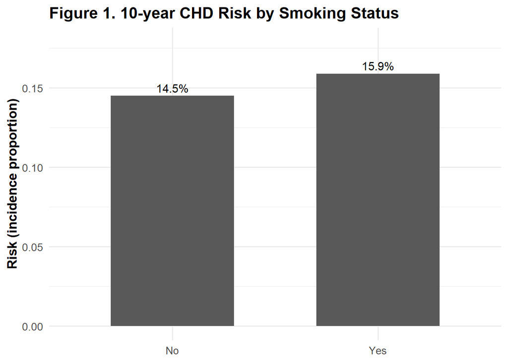

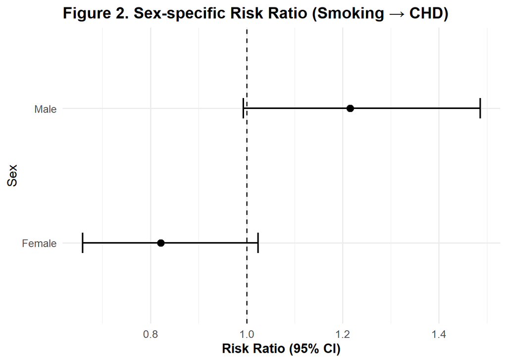

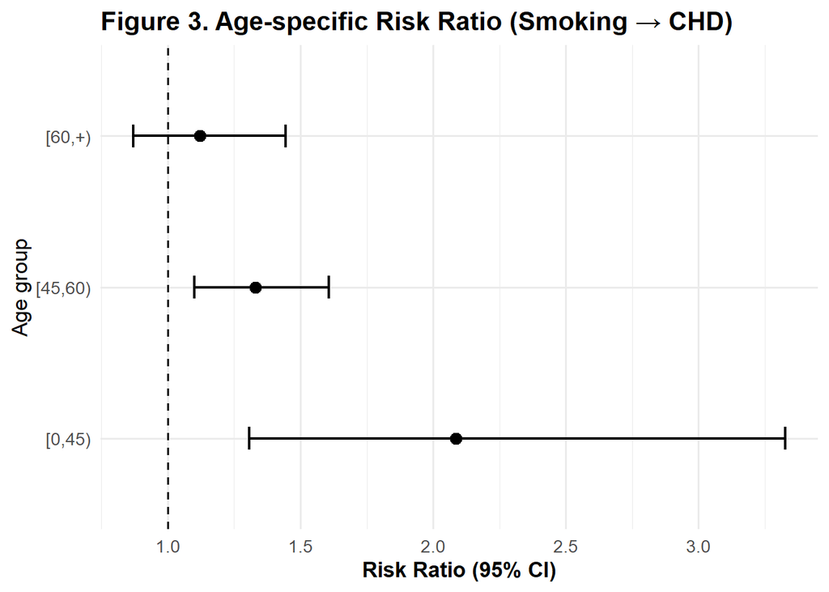

Figures saved to: H:_1_cohort_study